# Table of Contents

# Cette analyse va nous permettre de comprendre si certaines periodes sont pourvoyeuses de ventes ou pas

Ainsi , pourrons nous proposer des actions idoines en lien avec les periodes

```python
#Nous creeons  une copie de notre table
#Ensuite  nous transformons la colonne date en  ligne de sorte  à  avoir une  ligne representant un individu
#Cela nous  permet  d'avoir  une clé  principale avec des informante de date  et  les attributs de  l'individu  en colonne
#Ainsi nous realisons  un groupement de  notre table sur  la clé de date

datasaison= datap4V.copy()
datasaison=datasaison.set_index('date')
datasaison.head()
```

| date | id_prod | price | categ | session_id | client_id | sex | birth | age | ageclas |
| --- | --- | --- | --- | --- | --- | --- | --- | --- | --- |
| 2021-04-10 18:37:28.723910 | 0_1483 | 4.99 | 0.0 | s_18746 | c_4450 | f | 1977 | 44 | (40, 50] |
| 2021-12-27 11:11:12.123067 | 0_1483 | 4.99 | 0.0 | s_140787 | c_5433 | f | 1981 | 40 | (30, 40] |
| 2021-10-27 04:56:38.293970 | 0_1483 | 4.99 | 0.0 | s_110736 | c_857 | m | 1985 | 36 | (30, 40] |
| 2021-07-04 06:43:45.676567 | 0_1483 | 4.99 | 0.0 | s_57626 | c_3679 | f | 1989 | 32 | (30, 40] |
| 2021-09-19 08:45:43.735331 | 0_1483 | 4.99 | 0.0 | s_92165 | c_1609 | m | 1980 | 41 | (40, 50] |

```python
#Nous avons notre table qui regroippe  la colonne date
#Nous aimerionss avoir  les operations (transactions ) realisées
#ces  operations  , nous les classerons  par  mois  de sorte à voir le flux  des operations sur  une année
#Pour  y arriver  , nous  grouppons notre df  autour des clés de mois et d'année pour avoir  les resultats  commerciaux mensuels
#Nous  passons  la somme en argument afin d'avoir   l'ensemble des ventes de  livres  mensuels

dfsaisongr= datasaison.groupby(by=[datasaison.index.year, datasaison.index.month])['price'].sum()
dfsaisongr.head(20)
```

```
date  date
2021  3       479312.03
      4       472980.72
      5       489367.95
      6       481257.94
      7       480898.66
      8       479305.19
      9       502771.28
      10      319159.96
      11      512890.17
      12      522937.68
2022  1       522955.31
      2       532740.88
Name: price, dtype: float64
```

Le groupement nous liste des operations avec des montants mesnsuels de ventes.Les ventes sont classées mensuelleemnt et nous permet de saisir et observer les flux commerciaux.Il apparait que le CA minimum equivaut à Octobre 2021 quand le plus grand CA a été realisé en fevrier 2022. Pour capturer ce flux de resultats commerciaux mensuels , nous allons les representer graphiquement

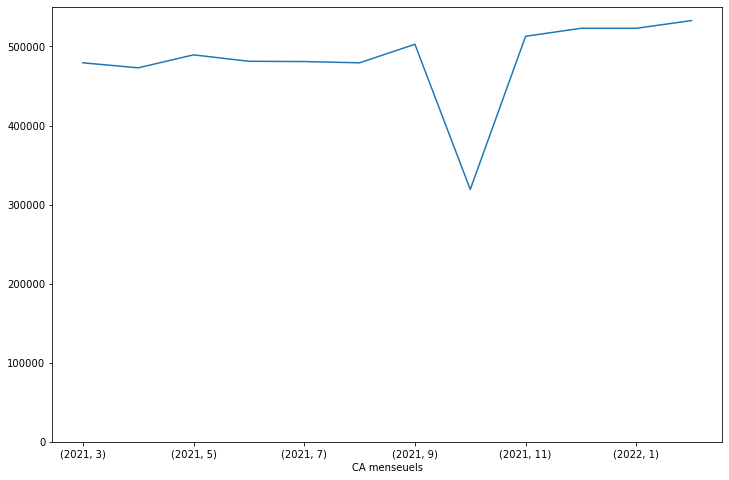

```python
#Representons les chiffres d'affaire mensuels
#Nous delimitons le graphique  pour  mieux  cerner  toutes  les  operations

plt.figure(figsize=(12,8))
dfsaisongr.plot()
plt.xlabel('CA menseuels')
plt.ylim([0,550000])
plt.show()
plt.savefig('serie temporelle des CA.jpg')
```

Le graphique montre une tendance à la hausse du CA sauf en octobre ou nous constatons un certain effondrement de celui-ci.Nous ne savons pas si cette chute du CA est due à des meventes ou à d'autres problemes notamment de fournisseurs , de concurrence ou autre. Nous decidons de pousser nos reflexions

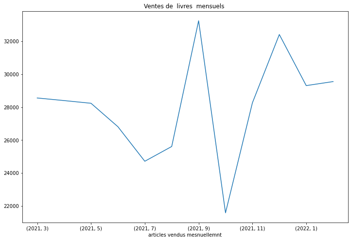

```python
#Nous decidons  de  lister  le  nombre de  produit  veendus pour savoir  davantage les raisons  de  la decrue  du  CA en octobre
#Nous allons donc compter le nombre d'article  mensuels  vendus
#Pour cela  nous grouppons en comptant
data4saison= datasaison.groupby(by=[datasaison.index.year, datasaison.index.month])['price'].count()
plt.figure(figsize=(12,8))
data4saison.plot()
plt.title('Ventes de  livres  mensuels ')
plt.xlabel('articles vendus mesnuellemnt')
plt.show()
plt.savefig('nombre articles vendus  mensuelleemnt.jpg')
```

le graphique nous indique un flux de ventes d'articles en forme de dents de scie ou plusieurs evolutions sont notables .On observe une tendance à la baisse jusqu'en jullet et une forte hausse en septembre pour ensuite baisser drastiquement en octobre.Ensuite une evolution des ventes s'observe pour ensuute decroitre en janvier 2022. Nous pourrons imaginer que pendant la rentrée scolaire , les ventes s'accroissent et en fin d'année pendant les periodes de fin d'année et de noel où beaucoup de personnes font des cadeaux notamment de livres .

# Couple 3 [prix-categorie]

```python
#Calculons   pour  les variables de prix et  de  categorie
#Nous avons  un couple de qualitative et  quantitative
#Ainsi  nous allons  calculer  l'eta squared
#Calcul  de  l'eta  carré
X = "categ" # qualitative
Y = "price" # quantitative

sous_echantillon = datap4V.copy()

def eta_squared(x,y):
    moyenne_y = y.mean()
    classes = []
    for classe in x.unique():
        yi_classe = y[x==classe]
        classes.append({'ni': len(yi_classe),
                        'moyenne_classe': yi_classe.mean()})
    SCT = sum([(yj-moyenne_y)**2 for yj in y])
    SCE = sum([c['ni']*(c['moyenne_classe']-moyenne_y)**2 for c in classes])
    return SCE/SCT

eta_squared(sous_echantillon[X],sous_echantillon[Y])
```

```
0.6443264127453414
```

Maintenant , representons le graphique de cette observation et du calcul de l'eta carré

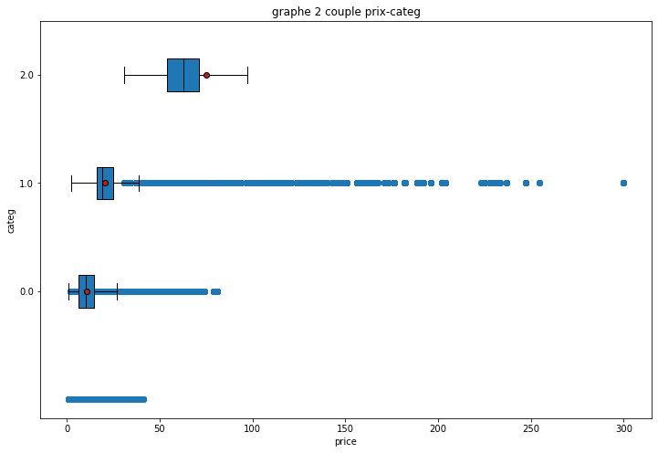

```python
#Visualisons  les  representations  de ce  couple
plt.figure(figsize=(12,8))
plt.plot(datap4V['price'], datap4V['categ'],'o', alpha =2.0)
plt.title('graphe 2 couple prix-categ')
X = "categ" # qualitative
Y = "price" # quantitative
# On ne garde que les dépenses
sous_echantillon = datap4V.copy() #On ne garde que  la colonne price
modalites = sous_echantillon[X].unique()
groupes = []
for m in modalites:
    groupes.append(sous_echantillon[sous_echantillon[X]==m][Y])

# Propriétés graphiques (pas très importantes)
medianprops = {'color':"black"}
meanprops = {'marker':'o', 'markeredgecolor':'black',
            'markerfacecolor':'firebrick'}

plt.boxplot(groupes, labels=modalites, showfliers=False, medianprops=medianprops,
            vert=False, patch_artist=True, showmeans=True, meanprops=meanprops)
plt.xlabel('price')
plt.ylabel('categ')
plt.show()
plt.savefig('graphe2bivarprixcateg.jpeg')
```

# Interpretation

Donc à la question de savoir: en connaissant la categorie d'un produit , est ce qu'on peut se projeter sur le montant des achats dess produits de cette categorie ?  
On pourrait repondre que probablement oui. il peut donc exister une relation meme si elle n'est pas lineaire. En outre , nous avions precedemment observé que les ages des clients au sein de la categorie 2 tournaaient autour de 20 ans et que cette tranche d'age depensait plus que les autres dans les categories 0 et 1.

# Couple 4 [sexe-categorie]

```python
#Ce couple  represnte deux variables qualitatives , toutes des  qualitatives  nominales  .
#ce qui  nous conduit  à dresser  un  tableau de contingence  pour avoir  les  diffeents effectifs et proportions des  modalités.
#Calculons  et  representons  le  tableau
X = "sex"
Y = "categ"

cont = datap4V[[X,Y]].pivot_table(index=X,columns=Y,aggfunc=len,margins=True,margins_name="Total")
cont
```

| categ sex | 0.0 | 1.0 | 2.0 | Total |
| --- | --- | --- | --- | --- |
| f | 103786 | 55469 | 8260 | 167515 |
| m | 105640 | 54266 | 9292 | 169198 |
| Total | 209426 | 109735 | 17552 | 336713 |

```
81.86933350990711
```

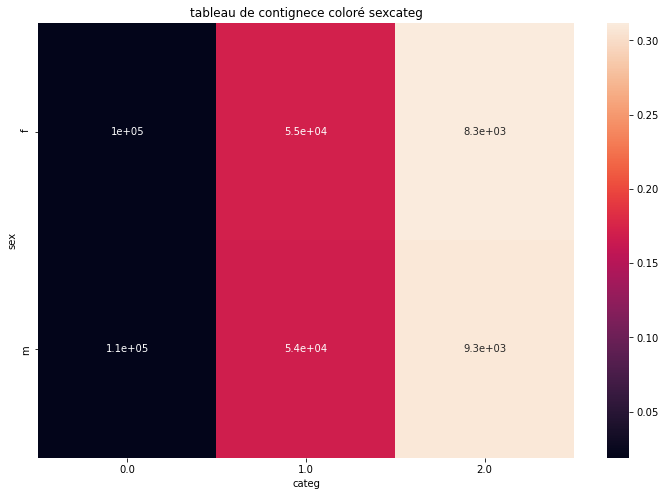

```python
#Representons  le tableau de contingence
import seaborn as sns
plt.figure(figsize=(12,8))
plt.title('tableau de contignece coloré sexcateg')
tx = cont.loc[:,["Total"]]
ty = cont.loc[["Total"],:]
n = len(datap4V)
indep = tx.dot(ty) / n

c = cont.fillna(0) # On remplace les valeurs nulles par 0
measure = (c-indep)**2/indep
xi_n = measure.sum().sum()
print(xi_n)
table = measure/xi_n
sns.heatmap(table.iloc[:-1,:-1],annot=c.iloc[:-1,:-1])
plt.show()
plt.savefig('heatmap de sexetcateg.jpg')
```

# Interpretation

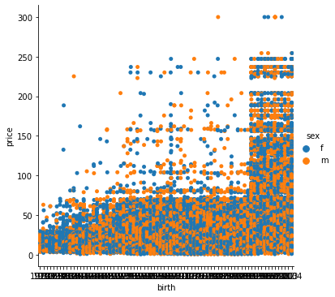

```python
#Representation graphique pour  illustrer  notre  interpretation
sns.catplot(x='birth',y='price',data= datap4V,hue='sex')
```

# Couple 5 sex-price

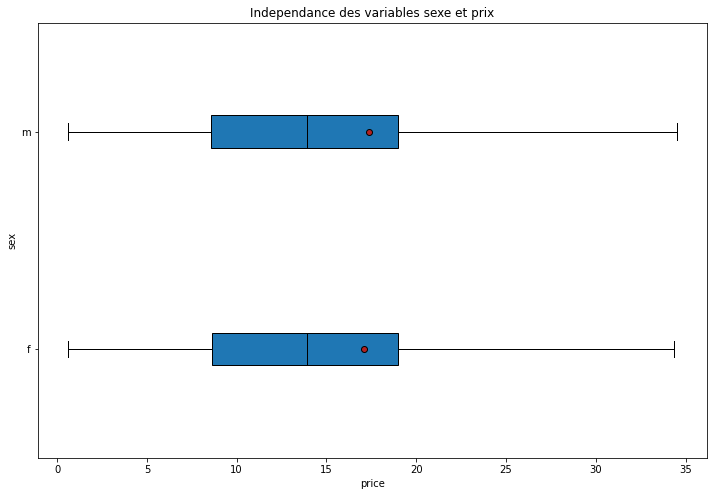

```python
#Pour  illustrer  ce couple  nous alons en  premier  creer  un sous-echantillon
X= 'sex'
Y= 'price'
sous_echantillon = datap4V.copy()
modalites= sous_echantillon[X].unique()
groupes =[]
for m in modalites:
     groupes.append(sous_echantillon[sous_echantillon[X]==m][Y])

medianprops = {'color':"black"}
meanprops = {'marker':'o', 'markeredgecolor':'black',
            'markerfacecolor':'firebrick'}
plt.figure(figsize=(12,8))
plt.boxplot(groupes, labels=modalites, showfliers=False, medianprops=medianprops,
            vert=False, patch_artist=True, showmeans=True, meanprops=meanprops)
plt.title('Independance des variables sexe et prix')
plt.xlabel('price')
plt.ylabel('sex')
plt.show()
plt.savefig('graphe4bivarsexprix.jpg')
```

# Interpretation

# Sur le graphe on constate que les moyennes se situent au meme niveau dans les deux genres de sesxe

# Nous observons aussi que les montants des produits sont equivalents qu'on soit du sexe M ou F

# Nous observons la meme valeur de l'ecart interquartile dans les deux boites

# On constate aussi la meme forme de dispersion identitque dans les deux cas

```python
#Calculons  le rapport de  correlation a travers eta carré
X = 'sex'
Y = 'price'
sous_echantillon = datap4V.copy()

def eta_squared(x,y):
    moyenne_y = y.mean()
    classes = []
    for classe in x.unique():
        yi_classe = y[x==classe]
        classes.append({'ni': len(yi_classe),
                        'moyenne_classe': yi_classe.mean()})
    SCT = sum([(yj-moyenne_y)**2 for yj in y])
    SCE = sum([c['ni']*(c['moyenne_classe']-moyenne_y)**2 for c in classes])
    return SCE/SCT

eta_squared(sous_echantillon[X],sous_echantillon[Y])
```

```
6.740934192042128e-05
```

## Interpretation du test d'eta carré

ce resultats tres eproche de O , on peut dire qu'il y ' pas de correlation entre les deux varibles

# 'C'est la meme observation que nous avons faites sur le graphique

# Il y a donc independance des deux valeurs

# Mission 3 correlations

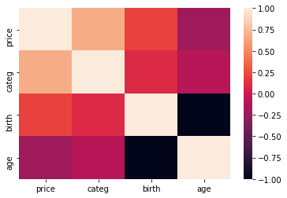

```python
#Visualisons  naivement des correlations à travers  une  forme  basique  de seaborn
sns.heatmap(datap4V.corr())
```

Ce heatmap indique très peu de correlations entre les variables . Excepté entre les variables categ et price qui peuvent presenter un degré d'acceptabilité de correlation.

# Coreelation age-Montant d'achat

```python
#Trouvons  le  nombre total d'achat  fait par client
#Nous allons d'abord  regroupé par client
#Ensuite  nous allons sommer  l'ensemble  de ce regroupement
#Pour cela  nous allons creer  un df qui reponds a notre  besoin
#Nous allons creer  un DF  client sans   la variable  birth
#Mais affichons d'abord  les colonnes afin de  les recuperer
datap4V.columns.unique()
```

```
Index(['id_prod', 'price', 'categ', 'date', 'session_id', 'client_id', 'sex',
       'birth', 'age', 'ageclas'],
      dtype='object')
```

```python
#A travers  une  restriction   modifions  notre  DF cient
dfclient = datap4V[[ 'id_prod', 'price', 'categ','client_id']]
dfclient.head()
```

|  | id_prod | price | categ | client_id |
| --- | --- | --- | --- | --- |
| 0 | 0_1483 | 4.99 | 0.0 | c_4450 |
| 1 | 0_1483 | 4.99 | 0.0 | c_5433 |
| 2 | 0_1483 | 4.99 | 0.0 | c_857 |
| 3 | 0_1483 | 4.99 | 0.0 | c_3679 |
| 4 | 0_1483 | 4.99 | 0.0 | c_1609 |

```python
#Avec cette  nouvelle df  client  je vais  grouper sur client id
dfclient_gr  = dfclient.groupby(by = 'client_id').sum()
dfclient_gr.head()
```

| client_id | price | categ |
| --- | --- | --- |
| c_1 | 300.65 | 6.0 |
| c_10 | 586.18 | 19.0 |
| c_100 | 222.87 | 5.0 |
| c_1000 | 980.02 | 36.0 |
| c_1001 | 1102.45 | 16.0 |

```python
#ce  nouveau  Df  contient  le  montant  par client  mais sans  les ages
#Nous allons  pour repondre a  la question  faire  une  jointure
#la jointure  se fera sur  une clé commune de  client_id en  faisant  une  inner joint
#Mais avant  affichons  l'autre  table de client  obtenu  dans  la  mission 1
df_client = pd.read_csv('customers.csv')
df_client.info()
df_client.head()
```

```
<class 'pandas.core.frame.DataFrame'>
RangeIndex: 8623 entries, 0 to 8622
Data columns (total 3 columns):
 #   Column     Non-Null Count  Dtype
---  ------     --------------  -----
 0   client_id  8623 non-null   object
 1   sex        8623 non-null   object
 2   birth      8623 non-null   int64
dtypes: int64(1), object(2)
memory usage: 202.2+ KB
```

|  | client_id | sex | birth |
| --- | --- | --- | --- |
| 0 | c_4410 | f | 1967 |
| 1 | c_7839 | f | 1975 |
| 2 | c_1699 | f | 1984 |
| 3 | c_5961 | f | 1962 |
| 4 | c_5320 | m | 1943 |

```python
#Nous allons  joindre ces deux tables à partir de  la clé commune client_id
dfclient_jn = pd.merge(dfclient_gr,df_client ,on = 'client_id' ,how = 'inner')
dfclient_jn.head()
```

|  | client_id | price | categ | sex | birth |
| --- | --- | --- | --- | --- | --- |
| 0 | c_1 | 300.65 | 6.0 | m | 1955 |
| 1 | c_10 | 586.18 | 19.0 | m | 1956 |
| 2 | c_100 | 222.87 | 5.0 | m | 1992 |
| 3 | c_1000 | 980.02 | 36.0 | f | 1966 |
| 4 | c_1001 | 1102.45 | 16.0 | m | 1982 |

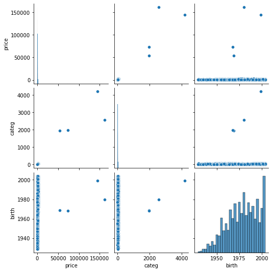

```python
#Nous allons representer  ce df  pour  visualiser  le total des achats  par client
#cela va certainement  nous  permttre  d'avoir  des  insight
sns.pairplot(dfclient_jn)
```

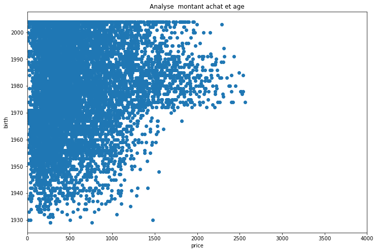

```python
#Representons un diagramme de dispersion  pour saisir  finement  les indicateurs
plt.figure(figsize=(12,8))
plt.plot(dfclient_jn['price'],dfclient_jn['birth'],'o',alpha=2.0)
plt.title('Analyse  montant achat et age')
plt.xlabel('price')
plt.ylabel('birth')
plt.xlim([0,4000])
plt.show()
plt.savefig('correlation agemontantAchat.jpg')
```

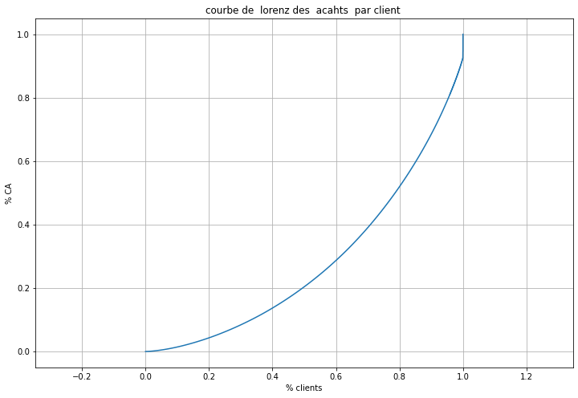

```python
#Avec ce  dataframe , nous allons representer  la courbe de  lorenz qui montre  les repartitions

#En effet  cette courbe  pourrait  nous indiquer l'indice de concentration sur  les achats
#La courbe de lorenz ici  nous  permettrait  de voir  la repartition des achats  par client
#Et nous  permettre de savoir les  montants par client et  ainsi  proposer  des actions  commerciales

depenses=dfclient_jn['price']
dep = depenses.values
n = len(dep)
lorenz = np.cumsum(np.sort(dep)) / dep.sum()
lorenz = np.append([0],lorenz) # La courbe de Lorenz commence à 0
plt.figure(figsize=(12,8))
plt.axes().axis('equal')
xaxis = np.linspace(0-1/n,1+1/n,n+1) #Il y a un segment de taille n pour chaque individu, plus 1 segment supplémentaire d'ordonnée 0. Le premier segment commence à 0-1/n, et le dernier termine à 1+1/n.
plt.plot(xaxis,lorenz,drawstyle='steps-post')
plt.title('courbe de  lorenz des  acahts  par client ')
plt.xlabel('% clients')
plt.ylabel('% CA')
plt.grid(True)
plt.show()
plt.savefig('graphe courbe de  lorenz sur  la variable  price.jpg')
```

```python
#Calculons  l'indice de  gini
AUC = (lorenz.sum() -lorenz[-1]/2 -lorenz[0]/2)/n # Surface sous la courbe de Lorenz. Le premier segment (lorenz[0]) est à moitié en dessous de 0, on le coupe donc en 2, on fait de même pour le dernier segment lorenz[-1] qui est à moitié au dessus de 1.
S = 0.5 - AUC # surface entre la première bissectrice et le courbe de Lorenz
gini = 2*S
gini
```

```
0.4397099070275071
```